# casestudy

# Question4 Compute the median alcohol content and international bitterness unit for each state. Plot a bar chart to compare.

The first tapply function takes the master_beer data set, looks at the ABV by state and stores the median into med.abv because that is what we have told the tapply to do. In the second tapply notice the code is the same except we now tell it to calculate the IBU value and save it into med.IBU.

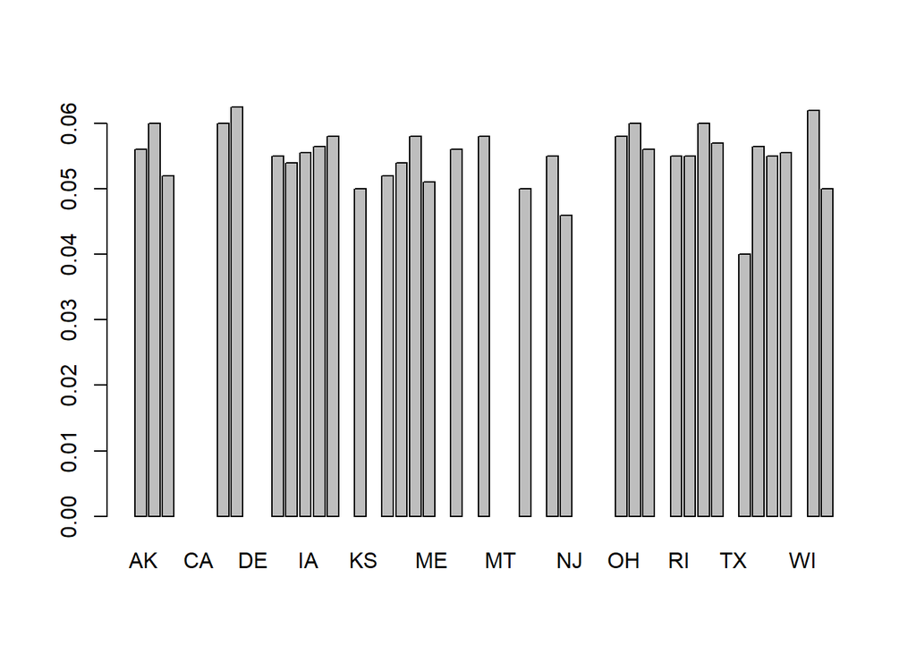

```r
med.abv<-tapply(master_beer$ABV, master_beer$State, median)
med.IBU<-tapply(master_beer$IBU, master_beer$State, median)
barplot(med.abv)
```

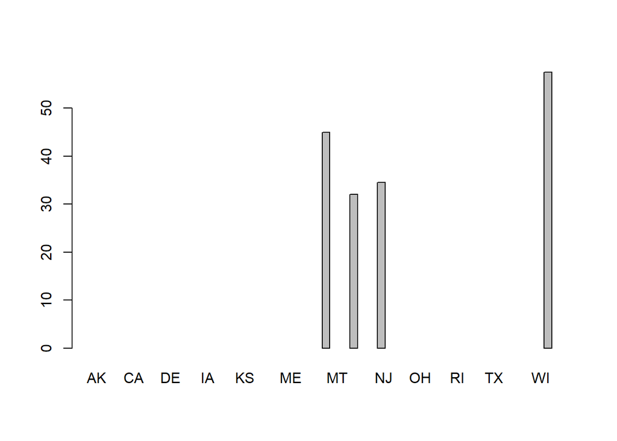

```r
barplot(med.IBU)
```

# Question5 Which state has the maximum alcoholic beer? Which state has the most bitter beer?

The R code below uses the function which.max and then the data we are looking at. The which function ranks the data variables and the max pulls out the max value and displays the row. Now we know which brewery has the highest ABV and IBU.

```r
master_beer[which.max(master_beer$ABV),]
```

```
##     Brew_ID                  Name.x    City State
## 384      52 Upslope Brewing Company Boulder    CO
##                                                   Name.y Beer_ID   ABV IBU
## 384 Lee Hill Series Vol. 5 - Belgian Style Quadrupel Ale    2565 0.128  NA
##                Style Ounces
## 384 Quadrupel (Quad)   19.2
```

```r
master_beer[which.max(master_beer$IBU),]
```

```
##      Brew_ID                  Name.x    City State
## 1857     375 Astoria Brewing Company Astoria    OR
##                         Name.y Beer_ID   ABV IBU
## 1857 Bitter Bitch Imperial IPA     980 0.082 138
##                               Style Ounces
## 1857 American Double / Imperial IPA     12
```

# Question6 Summary statistics for ABV (Alcohol by volume) variable.

```r
summary(master_beer$ABV)
```

```
##    Min. 1st Qu.  Median    Mean 3rd Qu.    Max.    NA's
## 0.00100 0.05000 0.05600 0.05977 0.06700 0.12800      62
```

# Question7 Is there a relationship between the bitterness of the beer and its alcoholic content? Draw a scatter plot.

Here is our scatter plot and a regression line which comes from “geom_smooth(method = lm)”. The scatter plot is defined by labeling our x and y axis from master_beer.

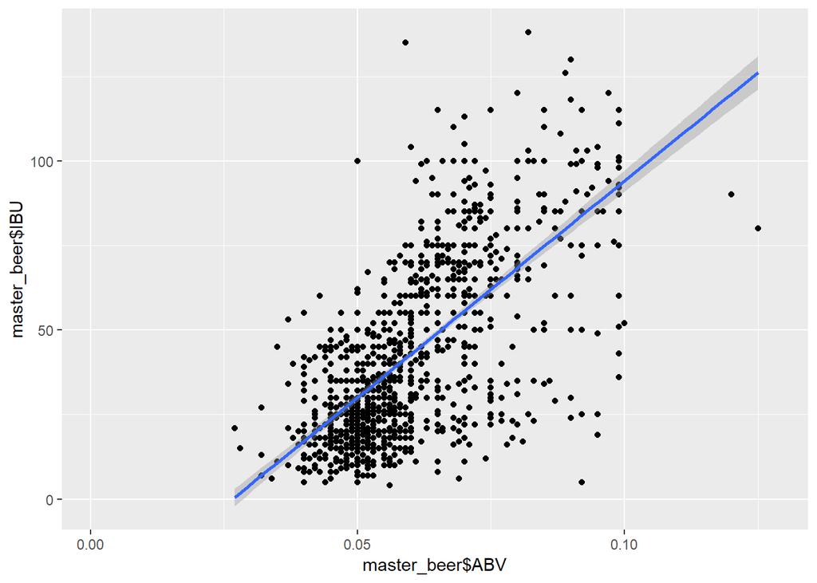

```r
ggplot(data = master_beer, mapping = aes(x = master_beer$ABV, y = master_beer$IBU))+
  geom_point() +
  geom_smooth(method = lm)
```

```r
cor.test(master_beer$ABV,master_beer$IBU)
```

```
##
##  Pearson's product-moment correlation
##
## data:  master_beer$ABV and master_beer$IBU
## t = 33.863, df = 1403, p-value < 2.2e-16
## alternative hypothesis: true correlation is not equal to 0
## 95 percent confidence interval:
##  0.6407982 0.6984238
## sample estimates:
##       cor
## 0.6706215
```

# Conclusion

It’s also worth noting that 1005 beers out of 2410 do not have an IBU value, but there is still 1405 observations with IBU which is a large sample still.